# Clase 02

[figure not shown]

Repaso calse 1

```
Tibles, filtrar y agrupar:
dplyr, filter, arrange, select, mutate,
summarise, group_by, ungroup,
```

Una versión actualizada de este material en : [clase02](https://mar71n.github.io/rconr/apuntes2026/clase02.html)

```r
#install.packages("dplyr")
library(dplyr)
#install.packages("readr")
library(readr)
#install.packages("lubridate")
library(lubridate)
#install.packages("ggplot2")
library(ggplot2)
```

### Datasets

#### Los individuales:

```r
#install.packages("readr")
library(readr)
```

```r
eah2025_ind <- read_csv2("./datos/eah2025_bu_ampliada/eah2025_bu_ampliada_ind.txt")
```

```
## ℹ Using "','" as decimal and "'.'" as grouping mark. Use `read_delim()` for more control.
```

```r
eah2025_hog <- read_csv2("./datos/eah2025_bu_ampliada/eah2025_bu_ampliada_hog.txt")
```

```
## ℹ Using "','" as decimal and "'.'" as grouping mark. Use `read_delim()` for more control.
```

#### Una primera mirada, según lo que esperemos, por lo general alguno de estos:

#### [readr::spec](https://readr.tidyverse.org/reference/spec.html)

```r
spec(eah2025_ind)
head(eah2025_ind)
```

```
## # A tibble: 6 × 237
##      id nhogar miembro comuna dominio  edad  sexo parentes_5  p5_2  p6_a  p6_b
##   <dbl>  <dbl>   <dbl>  <dbl>   <dbl> <dbl> <dbl>      <dbl> <dbl> <dbl> <dbl>
## 1     1      1       1      5       4    17     1          1     6    95    95
## 2     2      1       1      3       4    18     1          1     6     2    95
## 3     2      1       2      3       4    61     1          6     3     0     0
## 4     2      1       3      3       4    92     1          7     4     0     0
## 5     3      1       1      8       3    18     2          1     6    95     4
## 6     3      1       2      8       3    13     1          7     0    95     4
## # ℹ 226 more variables: t1 <dbl>, t2 <dbl>, t3 <dbl>, t4_1 <dbl>, t5_1 <dbl>,
## #   t5_1a <dbl>, t6_1 <dbl>, t7 <dbl>, t8 <dbl>, t9 <dbl>, t10 <dbl>,
## #   t11_0 <dbl>, t11_1 <dbl>, t12 <dbl>, estado <dbl>, t12_bis <dbl>,
## #   t11_2 <dbl>, t13_0 <dbl>, t13_0_espe <dbl>, t13 <dbl>, t14 <dbl>,
## #   t15 <dbl>, t18 <dbl>, t18_0 <dbl>, t19 <dbl>, t20_1 <dbl>, t21_1 <dbl>,
## #   t22_1 <dbl>, t48a_d <dbl>, t48b_d <dbl>, t48c_d <dbl>, t50d_a <dbl>,
## #   t50d_b <dbl>, t50d_c <dbl>, t50d_d <dbl>, t50d_e <dbl>, t50d_f <dbl>, …
```

```r
summary(eah2025_ind)
```

```
##        id           nhogar         miembro           comuna
##  Min.   :   1   Min.   :1.000   Min.   : 1.000   Min.   : 1.000
##  1st Qu.:1413   1st Qu.:1.000   1st Qu.: 1.000   1st Qu.: 4.000
##  Median :2507   Median :1.000   Median : 2.000   Median : 8.000
##  Mean   :2569   Mean   :1.007   Mean   : 2.017   Mean   : 7.517
##  3rd Qu.:3706   3rd Qu.:1.000   3rd Qu.: 3.000   3rd Qu.:11.000
##  Max.   :5475   Max.   :5.000   Max.   :11.000   Max.   :15.000
##     dominio           edad            sexo         parentes_5
##  Min.   :3.000   Min.   :  0.0   Min.   :1.000   Min.   :1.000
##  1st Qu.:4.000   1st Qu.: 22.0   1st Qu.:1.000   1st Qu.:1.000
##  Median :4.000   Median : 40.0   Median :2.000   Median :2.000
##  Mean   :3.878   Mean   : 40.7   Mean   :1.532   Mean   :2.238
##  3rd Qu.:4.000   3rd Qu.: 58.0   3rd Qu.:2.000   3rd Qu.:3.000
##  Max.   :4.000   Max.   :100.0   Max.   :2.000   Max.   :9.000
##       p5_2            p6_a            p6_b              t1
##  Min.   :0.000   Min.   : 0.00   Min.   : 0.000   Min.   :0.000
##  1st Qu.:1.000   1st Qu.: 0.00   1st Qu.: 0.000   1st Qu.:1.000
##  Median :2.000   Median : 0.00   Median : 0.000   Median :1.000
##  Mean   :2.985   Mean   :11.41   Mean   : 4.996   Mean   :1.317
##  3rd Qu.:6.000   3rd Qu.: 1.00   3rd Qu.: 1.000   3rd Qu.:2.000
##  Max.   :9.000   Max.   :95.00   Max.   :95.000   Max.   :2.000
##        t2               t3              t4_1              t5_1
##  Min.   :0.0000   Min.   :0.0000   Min.   :0.00000   Min.   :0.0000000
##  1st Qu.:0.0000   1st Qu.:0.0000   1st Qu.:0.00000   1st Qu.:0.0000000
##  Median :0.0000   Median :0.0000   Median :0.00000   Median :0.0000000
##  Mean   :0.7884   Mean   :0.6182   Mean   :0.02224   Mean   :0.0004014
##  3rd Qu.:2.0000   3rd Qu.:1.0000   3rd Qu.:0.00000   3rd Qu.:0.0000000
##  Max.   :2.0000   Max.   :5.0000   Max.   :7.00000   Max.   :2.0000000
##      t5_1a                t6_1                 t7               t8
##  Min.   :0.0000000   Min.   :0.0000000   Min.   :0.0000   Min.   :0.000000
##  1st Qu.:0.0000000   1st Qu.:0.0000000   1st Qu.:0.0000   1st Qu.:0.000000
##  Median :0.0000000   Median :0.0000000   Median :1.0000   Median :0.000000
##  Mean   :0.0003211   Mean   :0.0004014   Mean   :0.5312   Mean   :0.003452
##  3rd Qu.:0.0000000   3rd Qu.:0.0000000   3rd Qu.:1.0000   3rd Qu.:0.000000
##  Max.   :2.0000000   Max.   :1.0000000   Max.   :2.0000   Max.   :2.000000
##        t9              t10             t11_0            t11_1
##  Min.   :0.0000   Min.   :0.0000   Min.   :0.0000   Min.   : 0.0000
##  1st Qu.:0.0000   1st Qu.:0.0000   1st Qu.:0.0000   1st Qu.: 0.0000
##  Median :0.0000   Median :0.0000   Median :0.0000   Median : 0.0000
##  Mean   :0.1539   Mean   :0.1162   Mean   :0.1699   Mean   : 0.2149
```

[output cut: 358 more lines]

```
##  Max.   :9.000   Max.   :9.000   Max.   :20.0000   Max.   :9.000
##       sn5             sn16            s28              s29
##  Min.   :0.000   Min.   :1.000   Min.   :0.0000   Min.   : 0.0000
##  1st Qu.:3.000   1st Qu.:2.000   1st Qu.:0.0000   1st Qu.: 0.0000
##  Median :5.000   Median :2.000   Median :0.0000   Median : 0.0000
##  Mean   :4.773   Mean   :2.357   Mean   :0.6617   Mean   : 0.7113
##  3rd Qu.:6.000   3rd Qu.:3.000   3rd Qu.:1.0000   3rd Qu.: 1.0000
##  Max.   :9.000   Max.   :9.000   Max.   :9.0000   Max.   :99.0000
##       dh1             dh2             dh3             fexp
##  Min.   :1.000   Min.   :1.000   Min.   :0.000   Min.   : 10.0
##  1st Qu.:1.000   1st Qu.:1.000   1st Qu.:4.000   1st Qu.:137.0
##  Median :2.000   Median :2.000   Median :4.000   Median :223.0
##  Mean   :1.531   Mean   :1.547   Mean   :3.446   Mean   :247.8
##  3rd Qu.:2.000   3rd Qu.:2.000   3rd Qu.:4.000   3rd Qu.:335.0
##  Max.   :3.000   Max.   :7.000   Max.   :6.000   Max.   :854.0
```

#### Filtros

#### con [*[*](https://www.rdocumentation.org/packages/base/versions/3.6.2/topics/Extract)

#### o con [*dplyr::filter*](https://dplyr.tidyverse.org/reference/filter.html)

```r
#install.packages("dplyr")
library(dplyr)
```

##### Subconjunto de datos donde todas las condiciones son VERDADERAS.

- ```r
  x <- tribble(
    ~A, ~B, ~C,
    #--|--|---
    "a", "t", 1,
    "a", "b", 1,
    "b", "u", 2,
    "c", NA, 3,
    "c", "b", 3
  )

  x
  ```

  ```
  ## # A tibble: 5 × 3
  ##   A     B         C
  ##   <chr> <chr> <dbl>
  ## 1 a     t         1
  ## 2 a     b         1
  ## 3 b     u         2
  ## 4 c     <NA>      3
  ## 5 c     b         3
  ```

  ```r
  # Las dos condiciones son VERDADERAS
  x %>% filter(A == "a", B == "b")
  ```

  ```
  ## # A tibble: 1 × 3
  ##   A     B         C
  ##   <chr> <chr> <dbl>
  ## 1 a     b         1
  ```

  ```r
  # Equivalente a & (AND) con [
  x[x$A == "a" & x$B == "b",]
  ```

  ```
  ## # A tibble: 1 × 3
  ##   A     B         C
  ##   <chr> <chr> <dbl>
  ## 1 a     b         1
  ```

  ```r
  # Si la condicion es NA, el registro es excluido por filter (cosa esperable), pero no por [
  x$B == "t"
  ```

  ```
  ## [1]  TRUE FALSE FALSE    NA FALSE
  ```

  ```r
  x %>% filter(B == "t")
  ```

  ```
  ## # A tibble: 1 × 3
  ##   A     B         C
  ##   <chr> <chr> <dbl>
  ## 1 a     t         1
  ```

  ```r
  x[x$B == "t",]
  ```

  ```
  ## # A tibble: 2 × 3
  ##   A     B         C
  ##   <chr> <chr> <dbl>
  ## 1 a     t         1
  ## 2 <NA>  <NA>     NA
  ```

#### Podemos usar para construir las condiciones:

##### ==, >, <, >= …

##### &, |, !, xor()

##### is.na()

##### between(), near()

```r
eah2025_hog[eah2025_hog$v12 == 3,]
```

```
## # A tibble: 17 × 110
##       id nhogar comuna dominio  v2_2    v4   v12    h1    h2    h3 hacinam_2
##    <dbl>  <dbl>  <dbl>   <dbl> <dbl> <dbl> <dbl> <dbl> <dbl> <dbl>     <dbl>
##  1   527      1      4       4     9     1     3     2     2     1         2
##  2   763      1      9       3     1     2     3     1     3     2         1
##  3   771      1      8       3     1     1     3     1     3     1         3
##  4   944      1      4       3     2     2     3     1     2     2         2
##  5  1045      1      8       3     1     3     3     1     3     3         1
##  6  1137      1      8       3     1     2     3     1     3     2         2
##  7  1526      1      8       3     1     6     3     1     1     3         1
##  8  2284      1      9       4     1     3     3     1     3     3         1
##  9  2393      1      7       3     2     2     3     1     2     2         2
## 10  2487      1      4       3     1     2     3     1     3     2         2
## 11  2800      1      7       3     1     2     3     1     3     2         1
## 12  2801      1      4       3     1     1     3     1     3     1         2
## 13  3230      1      8       3     1     4     3     2     1     2         1
## 14  3318      1      7       3     9     3     3     2     2     3         1
## 15  3781      1      7       3     2     4     3     1     3     4         1
## 16  4024      1      1       3     2     1     3     1     2     1         1
## 17  4548      1      9       3     1     2     3     1     3     2         1
## # ℹ 99 more variables: tipoho_3 <dbl>, i_estratos <dbl>, i_canastas <dbl>,
## #   ca_canastas <dbl>, ct_canastas <dbl>, i_pobreza <dbl>, ca_pobreza <dbl>,
## #   ct_pobreza <dbl>, ent_rea_pm <dbl>, hog_per_0a17 <dbl>, hog_per_6a17 <dbl>,
## #   hog_per_0a12 <dbl>, hog_per_3a5 <dbl>, hog_per_15a17 <dbl>,
## #   hog_per_3a17 <dbl>, hpm2 <dbl>, hpm3 <dbl>, hpm1 <dbl>, hpm4 <dbl>,
## #   pm7 <dbl>, pm8 <dbl>, pm9 <dbl>, pm13 <dbl>, pm14 <dbl>, pm15 <dbl>,
## #   pm19 <dbl>, pm20 <dbl>, pm21 <dbl>, pm22 <dbl>, pm23 <dbl>, pm24 <dbl>, …
```

```r
eah2025_hog %>% filter(v12 == 3)
```

```
## # A tibble: 17 × 110
##       id nhogar comuna dominio  v2_2    v4   v12    h1    h2    h3 hacinam_2
##    <dbl>  <dbl>  <dbl>   <dbl> <dbl> <dbl> <dbl> <dbl> <dbl> <dbl>     <dbl>
##  1   527      1      4       4     9     1     3     2     2     1         2
##  2   763      1      9       3     1     2     3     1     3     2         1
##  3   771      1      8       3     1     1     3     1     3     1         3
##  4   944      1      4       3     2     2     3     1     2     2         2
##  5  1045      1      8       3     1     3     3     1     3     3         1
##  6  1137      1      8       3     1     2     3     1     3     2         2
##  7  1526      1      8       3     1     6     3     1     1     3         1
##  8  2284      1      9       4     1     3     3     1     3     3         1
##  9  2393      1      7       3     2     2     3     1     2     2         2
## 10  2487      1      4       3     1     2     3     1     3     2         2
## 11  2800      1      7       3     1     2     3     1     3     2         1
## 12  2801      1      4       3     1     1     3     1     3     1         2
## 13  3230      1      8       3     1     4     3     2     1     2         1
## 14  3318      1      7       3     9     3     3     2     2     3         1
## 15  3781      1      7       3     2     4     3     1     3     4         1
## 16  4024      1      1       3     2     1     3     1     2     1         1
## 17  4548      1      9       3     1     2     3     1     3     2         1
## # ℹ 99 more variables: tipoho_3 <dbl>, i_estratos <dbl>, i_canastas <dbl>,
## #   ca_canastas <dbl>, ct_canastas <dbl>, i_pobreza <dbl>, ca_pobreza <dbl>,
## #   ct_pobreza <dbl>, ent_rea_pm <dbl>, hog_per_0a17 <dbl>, hog_per_6a17 <dbl>,
## #   hog_per_0a12 <dbl>, hog_per_3a5 <dbl>, hog_per_15a17 <dbl>,
## #   hog_per_3a17 <dbl>, hpm2 <dbl>, hpm3 <dbl>, hpm1 <dbl>, hpm4 <dbl>,
## #   pm7 <dbl>, pm8 <dbl>, pm9 <dbl>, pm13 <dbl>, pm14 <dbl>, pm15 <dbl>,
## #   pm19 <dbl>, pm20 <dbl>, pm21 <dbl>, pm22 <dbl>, pm23 <dbl>, pm24 <dbl>, …
```

```r
eah2025_ind %>% filter(between(edad, 30, 35))
```

```
## # A tibble: 1,026 × 237
##       id nhogar miembro comuna dominio  edad  sexo parentes_5  p5_2  p6_a  p6_b
##    <dbl>  <dbl>   <dbl>  <dbl>   <dbl> <dbl> <dbl>      <dbl> <dbl> <dbl> <dbl>
##  1     8      1       2      6       4    33     1          7     1     0     0
##  2     8      1       3      6       4    30     2          7     1     0     0
##  3    20      1       3     10       4    30     2          7     1     0     0
##  4    92      1       5      9       4    31     2          7     6     0     0
##  5   104      1       3      9       4    35     2          8     1     0     0
##  6   174      1       4      9       4    30     1          7     6     0     0
##  7   221      1       2      3       4    33     1          8     6     0     0
##  8   224      1       2     14       4    33     2          8     6     0     0
##  9   254      1       8      8       3    30     1          2     1     0     0
## 10   260      1       2     14       4    33     1          2     1     0     0
## # ℹ 1,016 more rows
## # ℹ 226 more variables: t1 <dbl>, t2 <dbl>, t3 <dbl>, t4_1 <dbl>, t5_1 <dbl>,
## #   t5_1a <dbl>, t6_1 <dbl>, t7 <dbl>, t8 <dbl>, t9 <dbl>, t10 <dbl>,
## #   t11_0 <dbl>, t11_1 <dbl>, t12 <dbl>, estado <dbl>, t12_bis <dbl>,
## #   t11_2 <dbl>, t13_0 <dbl>, t13_0_espe <dbl>, t13 <dbl>, t14 <dbl>,
## #   t15 <dbl>, t18 <dbl>, t18_0 <dbl>, t19 <dbl>, t20_1 <dbl>, t21_1 <dbl>,
## #   t22_1 <dbl>, t48a_d <dbl>, t48b_d <dbl>, t48c_d <dbl>, t50d_a <dbl>, …
```

#### Frecuencias

##### Con [*base::table*](https://www.rdocumentation.org/packages/base/versions/3.6.2/topics/table)

```r
table(eah2025_ind$sexo)
```

```
##
##    1    2
## 5836 6621
```

```r
table(eah2025_ind$comuna)
```

```
##
##    1    2    3    4    5    6    7    8    9   10   11   12   13   14   15
## 1153  675  780 1216  631  707  969 1462  848  683  610  683  595  720  725
```

#### Al modo dplyr:

- [summarise](https://dplyr.tidyverse.org/reference/summarise.html) Resume cada grupo en menos filas.

  El resultado es una (o más) filas para cada combinación de variables de agrupación; si no hay variables de agrupación, la salida tendrá una sola fila que resuma todas las observaciones en la entrada. Contendrá una columna para cada variable de agrupación y una columna para cada una de las estadísticas de resumen que haya especificado. summarise() y summarize() son sinónimos.
- Funciones útiles
  - Centro: mean(), median()
  - Dispersión: sd(), IQR(), mad()
  - Rango: min(), max(), quantile()
  - Posición: first(), last(), nth()
  - Cuenta: n(), n_distinct()
  - Lógico: any(), all()

  ```r
  eah2025_ind %>% summarise(mean(edad))
  ```

  ```
  ## # A tibble: 1 × 1
  ##   `mean(edad)`
  ##          <dbl>
  ## 1         40.7
  ```

  ```r
  eah2025_ind %>% group_by(sexo) %>% summarise(mean(edad))
  ```

  ```
  ## # A tibble: 2 × 2
  ##    sexo `mean(edad)`
  ##   <dbl>        <dbl>
  ## 1     1         38.9
  ## 2     2         42.2
  ```

  ```r
  eah2025_ind %>% group_by(sexo) %>% summarise(n = n())
  ```

  ```
  ## # A tibble: 2 × 2
  ##    sexo     n
  ##   <dbl> <int>
  ## 1     1  5836
  ## 2     2  6621
  ```

  ```r
  eah2025_ind %>% group_by(sexo) %>% reframe(n = n())
  ```

  ```
  ## # A tibble: 2 × 2
  ##    sexo     n
  ##   <dbl> <int>
  ## 1     1  5836
  ## 2     2  6621
  ```

  ```r
  eah2025_ind %>% group_by(sexo) %>% reframe(qedad = quantile(edad))
  ```

  ```
  ## # A tibble: 10 × 2
  ##     sexo qedad
  ##    <dbl> <dbl>
  ##  1     1     0
  ##  2     1    20
  ##  3     1    38
  ##  4     1    56
  ##  5     1    98
  ##  6     2     0
  ##  7     2    23
  ##  8     2    42
  ##  9     2    60
  ## 10     2   100
  ```

- [group_by](https://dplyr.tidyverse.org/reference/group_by.html)

  group_by() toma un tbl existente y lo convierte en un tbl agrupado donde las operaciones se realizan “por grupo”. ungroup() elimina la agrupación.

  ```r
  # Agrupando por comuna
  # Conteo ponderado por comuna (población expandida)
  eah2025_ind %>%
    group_by(comuna) %>%
    count(wt = fexp)
  ```

  ```
  ## # A tibble: 15 × 2
  ## # Groups:   comuna [15]
  ##    comuna      n
  ##     <dbl>  <dbl>
  ##  1      1 259232
  ##  2      2 149398
  ##  3      3 193909
  ##  4      4 241184
  ##  5      5 188047
  ##  6      6 186005
  ##  7      7 242893
  ##  8      8 230775
  ##  9      9 171917
  ## 10     10 170914
  ## 11     11 190199
  ## 12     12 215516
  ## 13     13 236793
  ## 14     14 227350
  ## 15     15 182582
  ```

  ```r
  # Agrupando por comuna y sexo
  # Personas por comuna y sexo (dos variables de grupo)
  pob_comuna_sexo <- eah2025_ind %>%
    group_by(comuna, sexo) %>%
    count(wt = fexp)

  pob_comuna_sexo
  ```

  ```
  ## # A tibble: 30 × 3
  ## # Groups:   comuna, sexo [30]
  ##    comuna  sexo      n
  ##     <dbl> <dbl>  <dbl>
  ##  1      1     1 130749
  ##  2      1     2 128483
  ##  3      2     1  66575
  ##  4      2     2  82823
  ##  5      3     1  91919
  ##  6      3     2 101990
  ##  7      4     1 116192
  ##  8      4     2 124992
  ##  9      5     1  86891
  ## 10      5     2 101156
  ## # ℹ 20 more rows
  ```

  ```r
  # Transformo sexo en un factor
  eah2025_ind %>%
    mutate(sexo = factor(sexo, levels = c(1,2), labels =  c('Varon','Mujer'))) %>%
    group_by(comuna, sexo) %>%
    count(wt = fexp)
  ```

  ```
  ## # A tibble: 30 × 3
  ## # Groups:   comuna, sexo [30]
  ##    comuna sexo       n
  ##     <dbl> <fct>  <dbl>
  ##  1      1 Varon 130749
  ##  2      1 Mujer 128483
  ##  3      2 Varon  66575
  ##  4      2 Mujer  82823
  ##  5      3 Varon  91919
  ##  6      3 Mujer 101990
  ##  7      4 Varon 116192
  ##  8      4 Mujer 124992
  ##  9      5 Varon  86891
  ## 10      5 Mujer 101156
  ## # ℹ 20 more rows
  ```

- [count](https://dplyr.tidyverse.org/reference/count.html)

  *count()* le permite contar rápidamente los valores únicos de una o más variables: **df %>% count(a, b)** es aproximadamente *equivalente* a **df %>% group_by(a, b) %>% summarise(n = n() )**. *count()* está emparejado con tally(), un asistente de nivel inferior que es equivalente a df %>% summarise(n = n()).

  Pasamos un **wt** para ponderar, cambiando el resumen de n = n() a n = sum(wt).

  ```r
  eah2025_ind %>% count(sexo, wt = fexp)
  ```

  ```
  ## # A tibble: 2 × 2
  ##    sexo       n
  ##   <dbl>   <dbl>
  ## 1     1 1456604
  ## 2     2 1630110
  ```

  **count()** es una forma corta de hacer esto:

  ```r
  eah2025_ind %>% group_by(sexo) %>% summarise(n = sum(fexp))
  ```

  ```
  ## # A tibble: 2 × 2
  ##    sexo       n
  ##   <dbl>   <dbl>
  ## 1     1 1456604
  ## 2     2 1630110
  ```

#### Seleccionar columnas de interes, agregar columnas

##### [select()](https://dplyr.tidyverse.org/reference/select.html) y

##### [mutate()](https://dplyr.tidyverse.org/reference/mutate.html)

##### Crear, modificar y eliminar columnas.

##### **mutate()** agrega nuevas variables y conserva las existentes; Las nuevas variables sobrescriben las variables existentes del mismo nombre. Las variables se pueden eliminar estableciendo su valor en NULL

```r
eah2025_ind %>% select(sexo, edad, estado)
```

```
## # A tibble: 12,457 × 3
##     sexo  edad estado
##    <dbl> <dbl>  <dbl>
##  1     1    17      3
##  2     1    18      3
##  3     1    61      1
##  4     1    92      3
##  5     2    18      3
##  6     1    13      3
##  7     1    54      1
##  8     2    48      3
##  9     2    18      3
## 10     2    49      1
## # ℹ 12,447 more rows
```

```r
eah2025_ind %>% select(starts_with("i"))
```

```
## # A tibble: 12,457 × 24
##       id    i1    i4  i6_3  i7_0  i7_1  i7_2  i7_3   i10   i11  ioph_2
##    <dbl> <dbl> <dbl> <dbl> <dbl> <dbl> <dbl> <dbl> <dbl> <dbl>   <dbl>
##  1     1     0     0     0     0     0     0     0     0     0       0
##  2     2     0     0     0     0     0     0     0     0     0       0
##  3     2     1     0     1     2     1     2     0     0     0 3350000
##  4     2     0     0     0     0     0     0     0     0     0       0
##  5     3     0     0     0     0     0     0     0     0     0       0
##  6     3     0     0     0     0     0     0     0     0     0       0
##  7     3     0     0     0     0     0     0     0     2     0 1000000
##  8     3     0     0     0     0     0     0     0     0     0       0
##  9     4     0     0     0     0     0     0     0     0     0       0
## 10     4     0     0     0     0     0     0     0     2     0 1400000
## # ℹ 12,447 more rows
## # ℹ 13 more variables: ioph_neto_2 <dbl>, ios_2 <dbl>, ioa_2 <dbl>,
## #   inglab_2 <dbl>, i3_1x_2 <dbl>, i3_2x_2 <dbl>, i3_8x_2 <dbl>,
## #   i3_est_2 <dbl>, i3_otr_2 <dbl>, ingnolab_2 <dbl>, ingtot_2 <dbl>,
## #   itfb_2 <dbl>, ipcfb_2 <dbl>
```

```r
eah2025_ind %>%
  mutate(estado = factor(estado, levels= c(1:3), labels=c("Ocupado","Desocupado","Inactivo"))) %>%
  select(sexo, edad, estado)
```

```
## # A tibble: 12,457 × 3
##     sexo  edad estado
##    <dbl> <dbl> <fct>
##  1     1    17 Inactivo
##  2     1    18 Inactivo
##  3     1    61 Ocupado
##  4     1    92 Inactivo
##  5     2    18 Inactivo
##  6     1    13 Inactivo
##  7     1    54 Ocupado
##  8     2    48 Inactivo
##  9     2    18 Inactivo
## 10     2    49 Ocupado
## # ℹ 12,447 more rows
```

#### Ordenar

##### [dplyr::arrange()](https://dplyr.tidyverse.org/reference/arrange.html)

##### **arrange()** ordena las filas de un data frame por los valores de las columnas seleccionadas.

##### A diferencia de otros verbos dplyr, arrange() ignora en gran medida la agrupación; debe mencionar explícitamente las variables de agrupación (o usar .by_group = TRUE) para agruparlas. Las funciones se evaluan una vez para todos los datos, no por grupo.

##### Devuelve un data frame del mismo tipo que los datos de entrada.

- ```r
  x <- tribble(
    ~A, ~B, ~C,
    #--|--|---
    "a", "t", 1,
    "c", NA, 3,
    "b", "u", 2,
    "a", "b", 1,
    "c", "b", 3
  )

  x
  ```

  ```
  ## # A tibble: 5 × 3
  ##   A     B         C
  ##   <chr> <chr> <dbl>
  ## 1 a     t         1
  ## 2 c     <NA>      3
  ## 3 b     u         2
  ## 4 a     b         1
  ## 5 c     b         3
  ```

  ```r
  arrange(x, A)
  ```

  ```
  ## # A tibble: 5 × 3
  ##   A     B         C
  ##   <chr> <chr> <dbl>
  ## 1 a     t         1
  ## 2 a     b         1
  ## 3 b     u         2
  ## 4 c     <NA>      3
  ## 5 c     b         3
  ```

  ```r
  # Por ejemplo, las funciones de summarise se evaluan por grupo
  x %>% group_by(A) %>% summarise(sum(C))
  ```

  ```
  ## # A tibble: 3 × 2
  ##   A     `sum(C)`
  ##   <chr>    <dbl>
  ## 1 a            2
  ## 2 b            2
  ## 3 c            6
  ```

  ```r
  # arrange() no se evalua por grupo
  x %>% group_by(A, B) %>% arrange(A)
  ```

  ```
  ## # A tibble: 5 × 3
  ## # Groups:   A, B [5]
  ##   A     B         C
  ##   <chr> <chr> <dbl>
  ## 1 a     t         1
  ## 2 a     b         1
  ## 3 b     u         2
  ## 4 c     <NA>      3
  ## 5 c     b         3
  ```

  ```r
  # a menos que se indique con .by_group = TRUE
  x %>% group_by(A, B) %>% arrange(A, .by_group = TRUE)
  ```

  ```
  ## # A tibble: 5 × 3
  ## # Groups:   A, B [5]
  ##   A     B         C
  ##   <chr> <chr> <dbl>
  ## 1 a     b         1
  ## 2 a     t         1
  ## 3 b     u         2
  ## 4 c     b         3
  ## 5 c     <NA>      3
  ```

  ```r
  # La columna A ordenada
  sort(x$A)
  ```

  ```
  ## [1] "a" "a" "b" "c" "c"
  ```

  ```r
  # sort() no incluye los registros con NA
  sort(x$B)
  ```

  ```
  ## [1] "b" "b" "t" "u"
  ```

  ```r
  # arrange() ordena al final los NA
  arrange(x, B)
  ```

  ```
  ## # A tibble: 5 × 3
  ##   A     B         C
  ##   <chr> <chr> <dbl>
  ## 1 a     b         1
  ## 2 c     b         3
  ## 3 a     t         1
  ## 4 b     u         2
  ## 5 c     <NA>      3
  ```

  ```r
  # Se comporta igual que base::order()
  x[order(x$B),]
  ```

  ```
  ## # A tibble: 5 × 3
  ##   A     B         C
  ##   <chr> <chr> <dbl>
  ## 1 a     b         1
  ## 2 c     b         3
  ## 3 a     t         1
  ## 4 b     u         2
  ## 5 c     <NA>      3
  ```

##### [*options(…)*](https://www.rdocumentation.org/packages/base/versions/3.6.2/topics/options) nos permite ver y configurar opciones globales de R.

##### Entre ellas, *scipen*, con la que podemos controlar cuando usar notación cientifica.

##### *scipen*: Los valores positivos sesgan hacia la notación fija y los negativos hacia la notación científica: se preferirá la notación fija a menos que sea más que dígitos scipen más anchos.

##### Por defecto es cero.

```r
# guardo el valor actual
actual <- options("scipen")
# indico que use notación fija a menos que sean mas de 10 digitos:
options(scipen=10)
```

```r
# vuelvo a poner el valor anterior.
options(scipen=actual[[1]])
```

#### Un poco más de *ggplot*

##### *ggplot*, *aes*, *stat*, *position*, *facet*

```r
#install.packages("ggplot2")
library(ggplot2)
```

```r
dfa <- data.frame(v1 = c("a","b","c","a"), v2 = c(2,5,2,1))
dfa
```

```
##   v1 v2
## 1  a  2
## 2  b  5
## 3  c  2
## 4  a  1
```

#### *geom_bar* por defecto solo requiere *aes(x)* y hace un counteo. *stat =“count”*

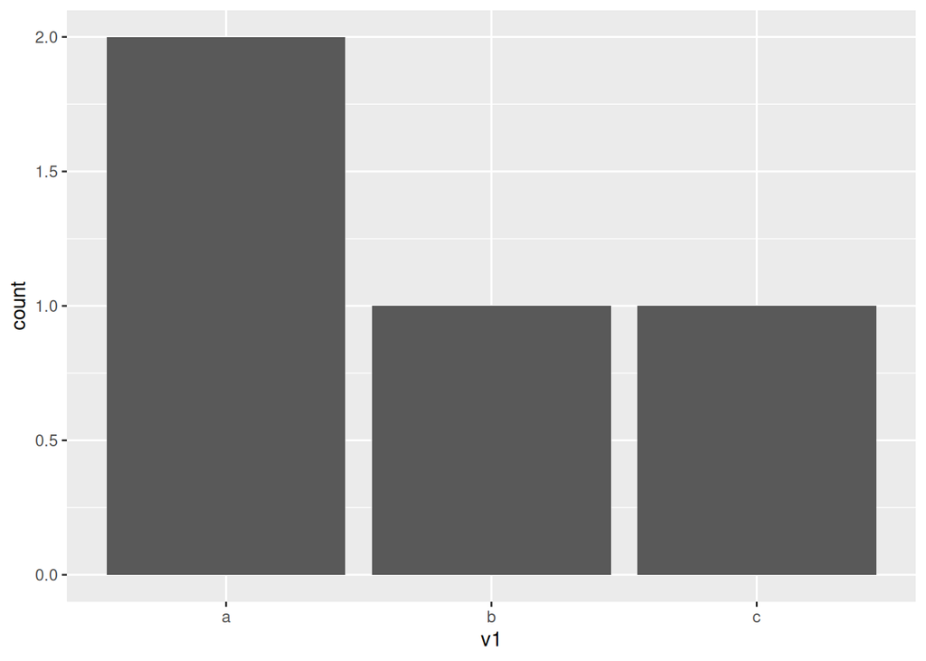

```r
ggplot(dfa, aes(v1)) +
  geom_bar()
```

##### El mismo gráfico con los valores por defecto explicitados:

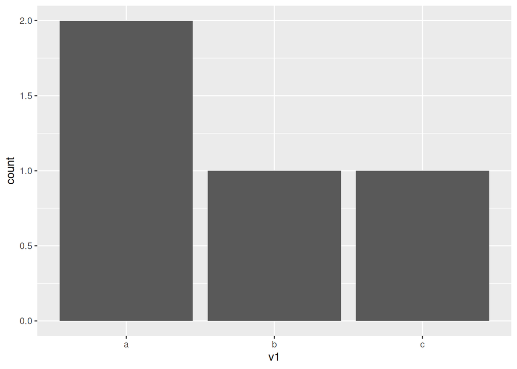

```r
ggplot(dfa, aes(v1)) +
  geom_bar(stat="count")
```

#### *geom_bar* con *stat = identity* agrupa por *x* ademas suma todos los casos

#### requiere *aes(x, y)*

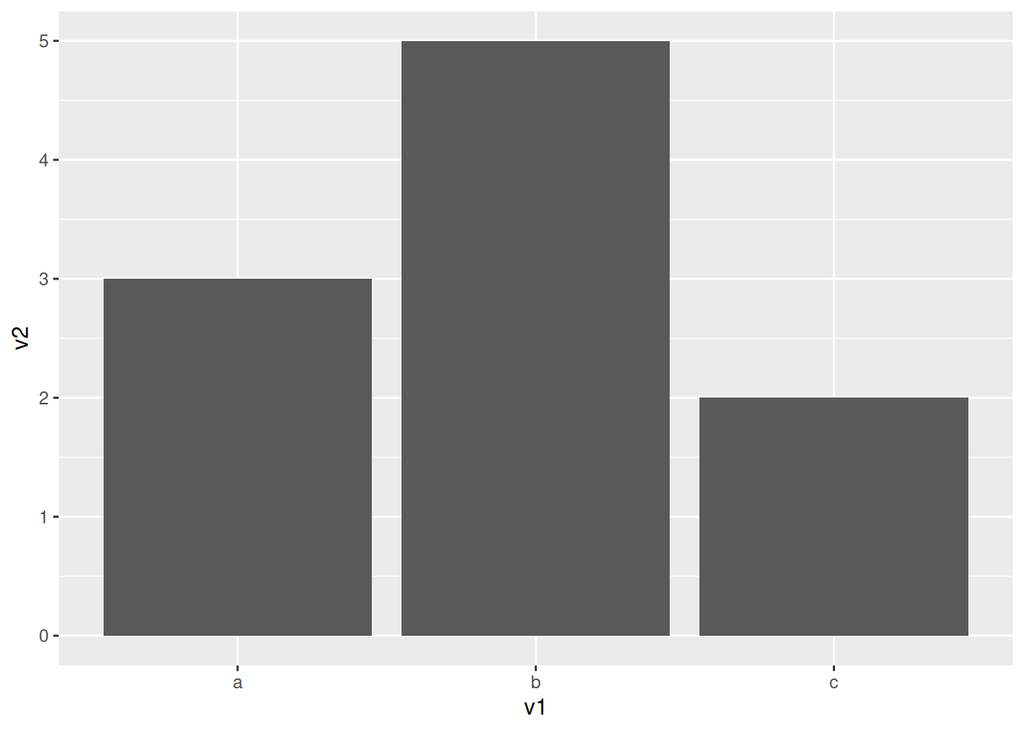

```r
ggplot(dfa, aes(v1, v2)) +
  geom_bar(stat="identity")
```

#### por defecto *position* es *“stack”*

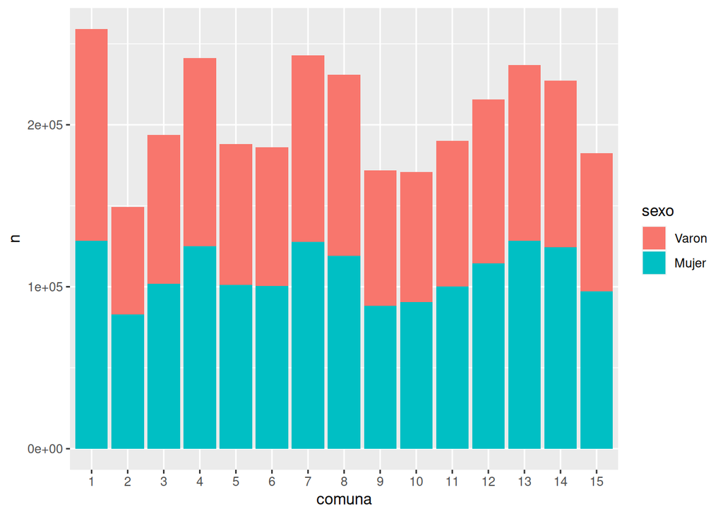

```r
library(ggplot2)

pob_comuna_sexo <- pob_comuna_sexo %>%
  mutate(sexo = factor(sexo, levels = c(1,2), labels =  c('Varon','Mujer'))) %>%
  mutate(comuna = factor(comuna))

pob_comuna_sexo %>%
  ggplot(aes(comuna, n, fill=sexo)) +
  geom_bar(stat="identity", position = "stack")
```

#### Con *position* = *“dodge”*

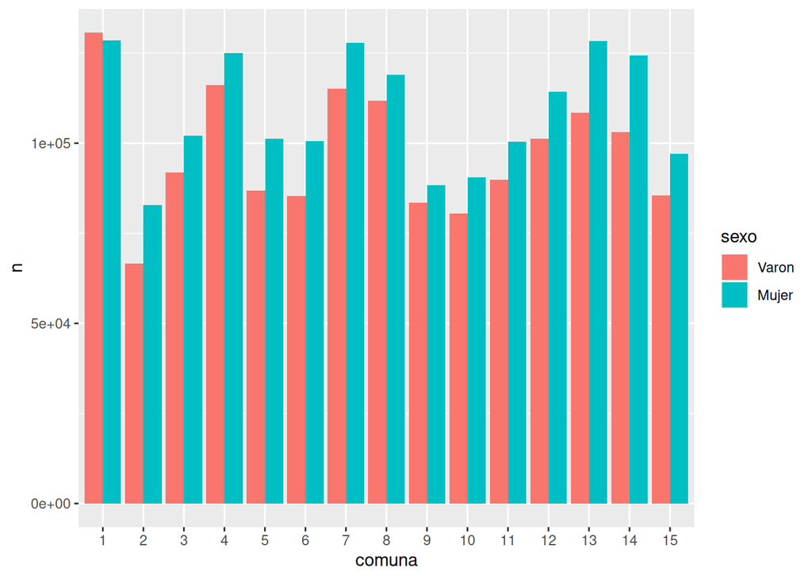

```r
pob_comuna_sexo %>%
  ggplot(aes(comuna, n, fill=sexo)) +
  geom_bar(stat="identity", position = "dodge")
```

#### Con *position* = *“fill”*

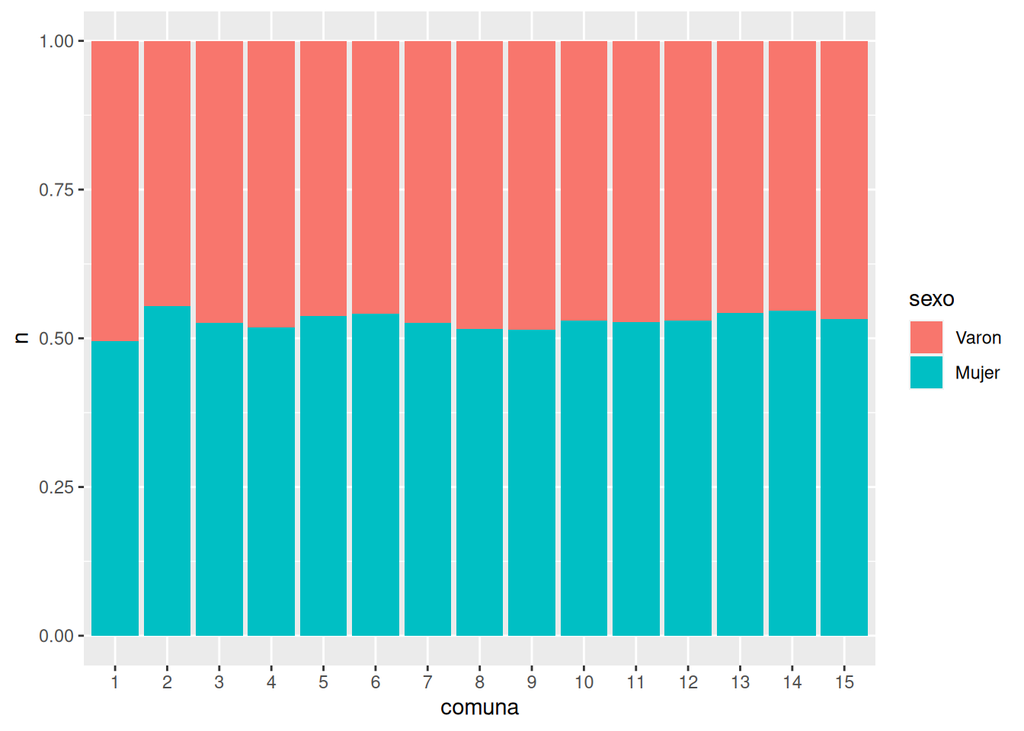

```r
pob_comuna_sexo %>%
  ggplot(aes(comuna, n, fill=sexo)) +
  geom_bar(stat="identity", position = "fill")
```

### Ejercicios

### Bibliografia:

#### [R para Ciencia de Datos - Cap 5 Transformación de datos](https://es.r4ds.hadley.nz/05-transform.html)

#### [Cheat Sheet *dplyr*](https://dplyr.tidyverse.org/index.html#cheat-sheet)

clase02.R

cuadro01.R

crear-cuadro-01.R

[figure not shown]